# Part I - Ford GoBike System Data

## Introduction

> Introduce the dataset The **Ford GoBike System Data** contains information about individual bike rides made in the Ford GoBike bike-sharing system covering the greater San Francisco Bay Area. The dataset includes trip duration, start/end times, station information, and rider demographics (gender, birth year, user type).

**Dataset source:** `201902-fordgobike-tripdata.csv`

### Questions I Want to Answer

1. **What is the distribution of trip durations?** Are most rides short, or do riders take long trips?
2. **When are bikes most used?** Which hours of the day and days of the week see peak demand?
3. **How does user type (Subscriber vs. Customer) affect ride behavior?** Do subscribers take shorter, more routine trips?
4. **What is the relationship between member age and trip duration?** Do younger riders take longer rides?
5. **How do gender and user type together influence trip duration?** Are there compounded differences?

## Preliminary Wrangling

```python
# import all packages and set plots to be embedded inline
import numpy as np
import pandas as pd
import matplotlib.pyplot as plt
import matplotlib.ticker as mticker
import seaborn as sns

%matplotlib inline

# Set global plot style
sns.set_style('whitegrid')
plt.rcParams['figure.figsize'] = (10, 6)
plt.rcParams['font.size'] = 12

print('Libraries loaded successfully.')
```

```
Libraries loaded successfully.
```

> Load in your dataset and describe its properties through the questions below. Try and motivate your exploration goals through this section.

> Note that the collective size of all your files in the current worksapce **must not exceed 1 GB** in total.

```python
# Load the dataset
df = pd.read_csv('201902-fordgobike-tripdata.csv')

# Display basic info
print(f'Shape: {df.shape}')
df.head()
```

```
Shape: (183412, 16)
```

|  | duration_sec | start_time | end_time | start_station_id | start_station_name | start_station_latitude | start_station_longitude | end_station_id | end_station_name | end_station_latitude | end_station_longitude | bike_id | user_type | member_birth_year | member_gender | bike_share_for_all_trip |
| --- | --- | --- | --- | --- | --- | --- | --- | --- | --- | --- | --- | --- | --- | --- | --- | --- |
| 0 | 52185 | 2019-02-28 17:32:10.1450 | 2019-03-01 08:01:55.9750 | 21.0 | Montgomery St BART Station (Market St at 2nd St) | 37.789625 | -122.400811 | 13.0 | Commercial St at Montgomery St | 37.794231 | -122.402923 | 4902 | Customer | 1984.0 | Male | No |
| 1 | 42521 | 2019-02-28 18:53:21.7890 | 2019-03-01 06:42:03.0560 | 23.0 | The Embarcadero at Steuart St | 37.791464 | -122.391034 | 81.0 | Berry St at 4th St | 37.775880 | -122.393170 | 2535 | Customer | NaN | NaN | No |
| 2 | 61854 | 2019-02-28 12:13:13.2180 | 2019-03-01 05:24:08.1460 | 86.0 | Market St at Dolores St | 37.769305 | -122.426826 | 3.0 | Powell St BART Station (Market St at 4th St) | 37.786375 | -122.404904 | 5905 | Customer | 1972.0 | Male | No |
| 3 | 36490 | 2019-02-28 17:54:26.0100 | 2019-03-01 04:02:36.8420 | 375.0 | Grove St at Masonic Ave | 37.774836 | -122.446546 | 70.0 | Central Ave at Fell St | 37.773311 | -122.444293 | 6638 | Subscriber | 1989.0 | Other | No |
| 4 | 1585 | 2019-02-28 23:54:18.5490 | 2019-03-01 00:20:44.0740 | 7.0 | Frank H Ogawa Plaza | 37.804562 | -122.271738 | 222.0 | 10th Ave at E 15th St | 37.792714 | -122.248780 | 4898 | Subscriber | 1974.0 | Male | Yes |

```python
# Inspect data types and non-null counts
df.info()
```

```
<class 'pandas.core.frame.DataFrame'>
RangeIndex: 183412 entries, 0 to 183411
Data columns (total 16 columns):
 #   Column                   Non-Null Count   Dtype
---  ------                   --------------   -----
 0   duration_sec             183412 non-null  int64
 1   start_time               183412 non-null  object
 2   end_time                 183412 non-null  object
 3   start_station_id         183215 non-null  float64
 4   start_station_name       183215 non-null  object
 5   start_station_latitude   183412 non-null  float64
 6   start_station_longitude  183412 non-null  float64
 7   end_station_id           183215 non-null  float64
 8   end_station_name         183215 non-null  object
 9   end_station_latitude     183412 non-null  float64
 10  end_station_longitude    183412 non-null  float64
 11  bike_id                  183412 non-null  int64
 12  user_type                183412 non-null  object
 13  member_birth_year        175147 non-null  float64
 14  member_gender            175147 non-null  object
 15  bike_share_for_all_trip  183412 non-null  object
dtypes: float64(7), int64(2), object(7)
memory usage: 22.4+ MB
```

```python
# Check for missing values per column
missing = df.isnull().sum()
print('Missing values per column:')
print(missing[missing > 0])
```

```
Missing values per column:
start_station_id       197
start_station_name     197
end_station_id         197
end_station_name       197
member_birth_year     8265
member_gender         8265
dtype: int64
```

### What is the structure of your dataset?

The dataset has **183,412 rows and 16 columns**. Each row represents one bike trip. Column types include:

- **Numeric:** `duration_sec`, `start_station_id`, `end_station_id`, `bike_id`, `member_birth_year`, plus start/end latitude and longitude.
- **String/Object:** `start_time`, `end_time` (timestamps stored as strings), `start_station_name`, `end_station_name`, `user_type`, `member_gender`, `bike_share_for_all_trip`.

There are missing values in `member_birth_year` (~8,265 rows) and `member_gender` (~8,265 rows). These appear to be the same rows and will be dropped during wrangling since they are needed for demographic analyses.

### What is/are the main feature(s) of interest in your dataset?

The **primary feature of interest** is `duration_sec` (converted to `duration_min`). I want to understand what drives trip length and how it varies across rider types and time periods.

A secondary focus is **ride demand patterns**, explored through `start_time` decomposed into `hour` and `day_of_week`.

### What features in the dataset do you think will help support your investigation into the feature(s) of interest?

| Feature | Role in Investigation |
| --- | --- |
| `user_type` | Subscriber vs. Customer — expected to be the strongest predictor of duration |
| `member_gender` | Demographic variable to test whether gender influences ride length |
| `member_birth_year` → `member_age` | Numeric demographic; used to test an age-duration relationship |
| `start_time` → `hour`, `day_of_week` | Temporal features to reveal commuter vs. leisure demand patterns |
| `duration_sec` → `duration_min` | The main outcome variable, converted to minutes for readability |

```python
def wrangle_gobike(dataframe):
    """
    Cleans and engineers features for the Ford GoBike dataset.

    Steps performed:
    - Converts start/end times to datetime
    - Derives hour, day_of_week, and date columns from start_time
    - Converts duration from seconds to minutes (duration_min)
    - Computes member_age from member_birth_year (reference year 2019)
    - Drops rows with missing member_gender or member_birth_year
    - Removes extreme duration outliers (keeps rides 1-120 minutes)
    - Removes unrealistic member ages (keeps ages 16-80)
    - Sets ordered categorical dtype for day_of_week
    - Converts user_type, member_gender, bike_share_for_all_trip to category dtype

    Parameters
    ----------
    dataframe : pd.DataFrame
        Raw Ford GoBike trip data.

    Returns
    -------
    pd.DataFrame
        Cleaned dataframe ready for exploration.
    """
    df = dataframe.copy()

    # Convert timestamps to datetime
    df['start_time'] = pd.to_datetime(df['start_time'])
    df['end_time']   = pd.to_datetime(df['end_time'])

    # Extract temporal features
    df['hour']        = df['start_time'].dt.hour
    df['day_of_week'] = df['start_time'].dt.day_name()
    df['date']        = df['start_time'].dt.date

    # Convert duration to minutes for readability
    df['duration_min'] = df['duration_sec'] / 60

    # Compute member age
    df['member_age'] = 2019 - df['member_birth_year']

    # Drop rows missing key demographic info
    df.dropna(subset=['member_gender', 'member_birth_year'], inplace=True)

    # Remove duration outliers: keep rides between 1 and 120 minutes
    df = df[(df['duration_min'] >= 1) & (df['duration_min'] <= 120)]

    # Remove unrealistic member ages
    df = df[(df['member_age'] >= 16) & (df['member_age'] <= 80)]

    # Set ordered categorical dtype for day of week
    day_order = ['Monday', 'Tuesday', 'Wednesday', 'Thursday', 'Friday', 'Saturday', 'Sunday']
    df['day_of_week'] = pd.Categorical(df['day_of_week'], categories=day_order, ordered=True)

    # Set categorical dtypes
    for col in ['user_type', 'member_gender', 'bike_share_for_all_trip']:
        if col in df.columns:
            df[col] = df[col].astype('category')

    return df


df = wrangle_gobike(df)
print(f'Cleaned shape: {df.shape}')
df.describe()
```

```
Cleaned shape: (174416, 21)
```

|  | duration_sec | start_time | end_time | start_station_id | start_station_latitude | start_station_longitude | end_station_id | end_station_latitude | end_station_longitude | bike_id | member_birth_year | hour | duration_min | member_age |
| --- | --- | --- | --- | --- | --- | --- | --- | --- | --- | --- | --- | --- | --- | --- |
| count | 174416.000000 | 174416 | 174416 | 174222.000000 | 174416.000000 | 174416.000000 | 174222.000000 | 174416.000000 | 174416.000000 | 174416.000000 | 174416.000000 | 174416.000000 | 174416.000000 | 174416.000000 |
| mean | 639.893261 | 2019-02-15 21:24:59.818508544 | 2019-02-15 21:35:40.210693120 | 139.022540 | 37.770778 | -122.351193 | 136.608367 | 37.770970 | -122.350764 | 4481.736504 | 1984.880785 | 13.456718 | 10.664888 | 34.119215 |
| min | 61.000000 | 2019-02-01 00:00:20.636000 | 2019-02-01 00:04:52.058000 | 3.000000 | 37.317298 | -122.453704 | 3.000000 | 37.317298 | -122.453704 | 11.000000 | 1939.000000 | 0.000000 | 1.016667 | 18.000000 |
| 25% | 323.000000 | 2019-02-08 08:31:42.088749824 | 2019-02-08 08:41:36.906749952 | 47.000000 | 37.770083 | -122.411901 | 44.000000 | 37.770407 | -122.411647 | 3802.000000 | 1980.000000 | 9.000000 | 5.383333 | 27.000000 |
| 50% | 509.000000 | 2019-02-15 21:58:06.832499968 | 2019-02-15 22:09:57.757500160 | 104.000000 | 37.780760 | -122.398279 | 101.000000 | 37.781010 | -122.397405 | 4959.000000 | 1987.000000 | 14.000000 | 8.483333 | 32.000000 |
| 75% | 785.000000 | 2019-02-22 11:19:16.370000128 | 2019-02-22 11:32:54.098249984 | 239.000000 | 37.797320 | -122.281193 | 238.000000 | 37.797673 | -122.285171 | 5504.000000 | 1992.000000 | 17.000000 | 13.083333 | 39.000000 |
| max | 7174.000000 | 2019-02-28 23:59:18.548000 | 2019-03-01 00:20:44.074000 | 398.000000 | 37.880222 | -121.874119 | 398.000000 | 37.880222 | -121.874119 | 6645.000000 | 2001.000000 | 23.000000 | 119.566667 | 80.000000 |
| std | 539.384294 | NaN | NaN | 111.611282 | 0.101188 | 0.118551 | 111.291746 | 0.101096 | 0.118114 | 1658.294200 | 9.876194 | 4.735310 | 8.989738 | 9.876194 |

## Univariate Exploration

I start by examining the distributions of individual variables before moving to relationships between them.

### Q1: What is the distribution of trip durations?

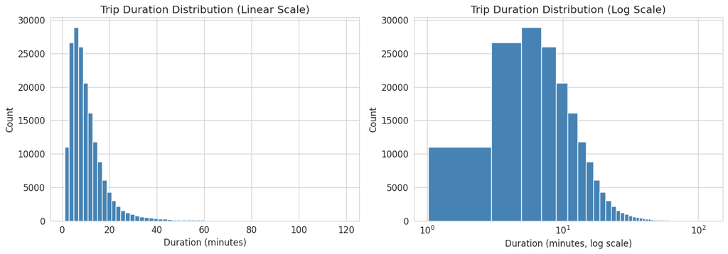

```python
def plot_duration_histogram(data, bins=60, color='steelblue'):
    """
    Plots side-by-side histograms of trip duration on linear and log x-axis scales.
    The log-scale panel reveals the full spread of a right-skewed distribution.

    Parameters
    ----------
    data  : pd.DataFrame with 'duration_min' column
    bins  : int, number of histogram bins
    color : str, bar fill color
    """
    fig, axes = plt.subplots(1, 2, figsize=(14, 5))

    # Linear scale
    axes[0].hist(data['duration_min'], bins=bins, color=color, edgecolor='white')
    axes[0].set_title('Trip Duration Distribution (Linear Scale)')
    axes[0].set_xlabel('Duration (minutes)')
    axes[0].set_ylabel('Count')

    # Log x-axis to reveal the right tail
    axes[1].hist(data['duration_min'], bins=bins, color=color, edgecolor='white')
    axes[1].set_xscale('log')
    axes[1].set_title('Trip Duration Distribution (Log Scale)')
    axes[1].set_xlabel('Duration (minutes, log scale)')
    axes[1].set_ylabel('Count')

    plt.tight_layout()
    plt.savefig('plot_01_duration_histogram.png', dpi=150, bbox_inches='tight')
    plt.show()


plot_duration_histogram(df)
```

**Observation:** Trip durations are strongly right-skewed. The vast majority of rides are under 20 minutes, with a mode around 5-10 minutes. The log-scale view confirms a smooth long tail with no isolated outlier clusters. This strongly suggests the system is used mainly for short utility trips.

### Q2: What is the distribution of member ages?

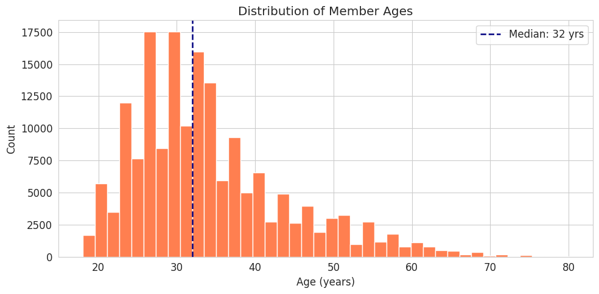

```python
def plot_age_histogram(data, bins=40, color='coral'):
    """
    Plots a histogram of member ages with a vertical median reference line.

    Parameters
    ----------
    data  : pd.DataFrame with 'member_age' column
    bins  : int, number of histogram bins
    color : str, bar fill color
    """
    fig, ax = plt.subplots(figsize=(10, 5))
    ax.hist(data['member_age'], bins=bins, color=color, edgecolor='white')
    ax.set_title('Distribution of Member Ages')
    ax.set_xlabel('Age (years)')
    ax.set_ylabel('Count')
    ax.axvline(data['member_age'].median(), color='navy', linestyle='--',
               linewidth=1.8, label=f"Median: {data['member_age'].median():.0f} yrs")
    ax.legend()
    plt.tight_layout()
    plt.savefig('plot_02_age_histogram.png', dpi=150, bbox_inches='tight')
    plt.show()


plot_age_histogram(df)
```

**Observation:** Member ages are roughly bell-shaped with a slight right skew, peaking in the late 20s to mid-30s. The median age is approximately 32-34 years, indicating that young working adults are the primary users.

### Q3: What is the breakdown of user types and gender?

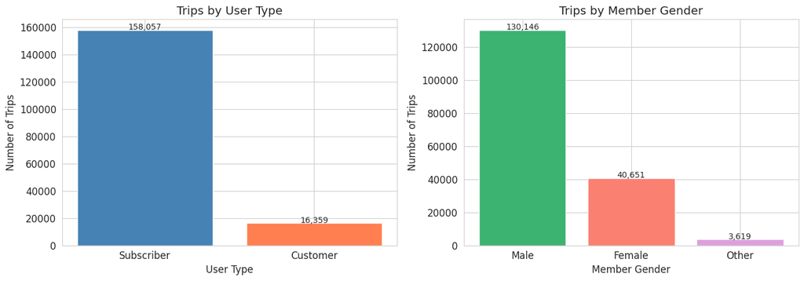

```python
def plot_categorical_counts(data, columns, titles, colors_list):
    """
    Plots annotated bar/count charts for a list of categorical columns.

    Parameters
    ----------
    data        : pd.DataFrame
    columns     : list of str, column names to plot
    titles      : list of str, chart titles
    colors_list : list of color lists, one per chart
    """
    fig, axes = plt.subplots(1, len(columns), figsize=(14, 5))

    for ax, col, title, colors in zip(axes, columns, titles, colors_list):
        counts = data[col].value_counts()
        ax.bar(counts.index, counts.values, color=colors, edgecolor='white')
        ax.set_title(title)
        ax.set_xlabel(col.replace('_', ' ').title())
        ax.set_ylabel('Number of Trips')
        # Annotate each bar with its count
        for i, val in enumerate(counts.values):
            ax.text(i, val + 200, f'{val:,}', ha='center', fontsize=10)

    plt.tight_layout()
    plt.savefig('plot_03_categorical_counts.png', dpi=150, bbox_inches='tight')
    plt.show()


plot_categorical_counts(
    df,
    columns=['user_type', 'member_gender'],
    titles=['Trips by User Type', 'Trips by Member Gender'],
    colors_list=[['steelblue', 'coral'], ['mediumseagreen', 'salmon', 'plum']]
)
```

### Discuss the distribution(s) of your variable(s) of interest. Were there any unusual points? Did you need to perform any transformations?

The `duration_min` distribution is heavily right-skewed with a mode around 5-10 minutes and a long tail extending to 120 minutes. A log transformation on the x-axis (shown in Q1) makes the full distribution much more readable and reveals a smooth, continuous decay — no isolated outlier clusters.

The `member_age` variable was approximately normally distributed after removing unrealistic values. A small number of birth years implied ages over 100 (e.g., birth year 1878), which are almost certainly data entry errors. These were capped at age 80 during wrangling.

### Of the features you investigated, were there any unusual distributions? Did you perform any operations on the data to tidy, adjust, or change the form of the data? If so, why did you do this?

Three cleaning decisions were made:

1. **Duration capped at 1–120 minutes:** A small number of rides exceeded several hours — likely bikes that were never docked or were misreported. Rides under 1 minute were also removed as likely false starts or system errors. Keeping these would severely distort visual scales without adding insight.
2. **Age capped at 16–80:** Some `member_birth_year` values implied ages of 141 years (birth year 1878), which are clearly erroneous input. These were removed to preserve the integrity of any age-based analyses.
3. **Missing demographics dropped:** Approximately 4.5% of rows were missing both `member_gender` and `member_birth_year`. These were dropped for analyses involving demographics. The remaining ~175,000 rows provide ample data for reliable conclusions.

Additionally, `start_time` was decomposed into `hour` and `day_of_week` to enable temporal demand analysis, and `duration_sec` was converted to `duration_min` for more intuitive interpretation.

## Bivariate Exploration

> In this section, investigate relationships between pairs of variables in your data. Make sure the variables that you cover here have been introduced in some fashion in the previous section (univariate exploration).

### Q4: Is there a relationship between member age and trip duration?

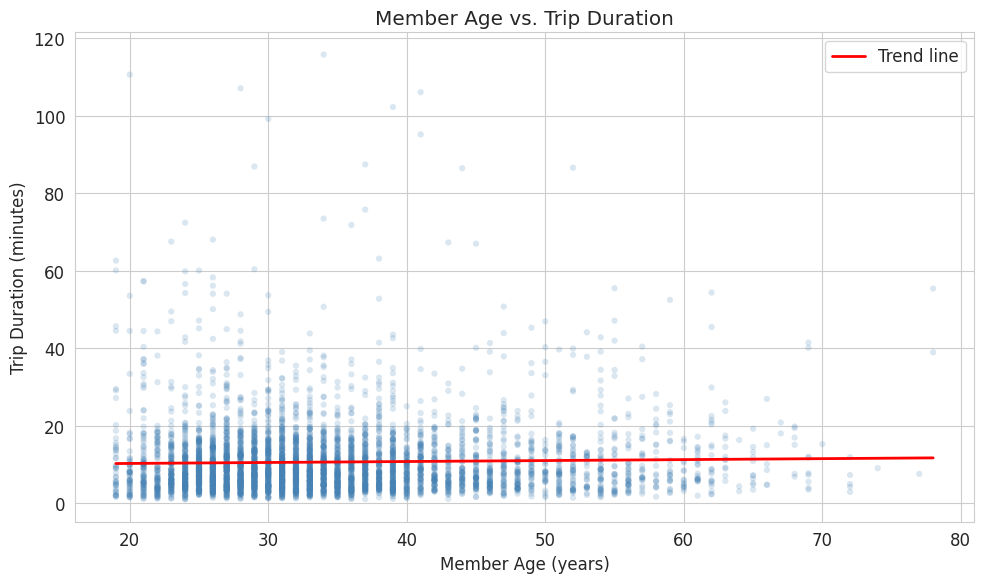

```
Pearson correlation (age vs. duration): 0.025
```

```python
def plot_age_vs_duration(data, sample_n=5000, alpha=0.2):
    """
    Scatter plot of member age vs. trip duration with a linear trend line.
    Uses a random sample to reduce overplotting on the full dataset.

    Parameters
    ----------
    data     : pd.DataFrame with 'member_age' and 'duration_min' columns
    sample_n : int, number of points to plot
    alpha    : float, point transparency
    """
    sample = data.sample(n=min(sample_n, len(data)), random_state=42)

    fig, ax = plt.subplots(figsize=(10, 6))
    ax.scatter(sample['member_age'], sample['duration_min'],
               alpha=alpha, color='steelblue', edgecolors='none', s=20)

    # Overlay linear trend line
    z = np.polyfit(sample['member_age'], sample['duration_min'], 1)
    p = np.poly1d(z)
    x_line = np.linspace(sample['member_age'].min(), sample['member_age'].max(), 100)
    ax.plot(x_line, p(x_line), color='red', linewidth=2, label='Trend line')

    ax.set_title('Member Age vs. Trip Duration')
    ax.set_xlabel('Member Age (years)')
    ax.set_ylabel('Trip Duration (minutes)')
    ax.legend()
    plt.tight_layout()
    plt.savefig('plot_04_scatter_age_duration.png', dpi=150, bbox_inches='tight')
    plt.show()

    corr = data['member_age'].corr(data['duration_min'])
    print(f'Pearson correlation (age vs. duration): {corr:.3f}')


plot_age_vs_duration(df)
```

**Observation:** There is no meaningful linear relationship between age and trip duration. The Pearson correlation is close to zero and the trend line is nearly flat. Long rides occur across all age groups, and the vertical spread of durations does not change significantly with age.

### Q5: How does trip duration differ between user types?

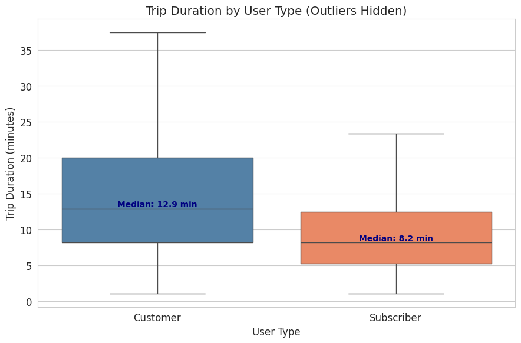

```python
def plot_duration_by_usertype(data):
    """
    Box plot comparing trip duration distributions for Subscribers vs. Customers.
    Extreme outliers are hidden to keep the IQR and median clearly visible.

    Parameters
    ----------
    data : pd.DataFrame with 'user_type' and 'duration_min' columns
    """
    fig, ax = plt.subplots(figsize=(9, 6))
    sns.boxplot(
    data=data,
    x='user_type',
    y='duration_min',
    hue='user_type',
    palette=['steelblue', 'coral'],
    legend=False,
    ax=ax,
    showfliers=False
)

    ax.set_title('Trip Duration by User Type (Outliers Hidden)')
    ax.set_xlabel('User Type')
    ax.set_ylabel('Trip Duration (minutes)')

    # Annotate median values on each box
    medians = data.groupby('user_type')['duration_min'].median()
    for i, (utype, med) in enumerate(medians.items()):
        ax.text(i, med + 0.3, f'Median: {med:.1f} min',
                ha='center', fontsize=10, color='navy', fontweight='bold')

    plt.tight_layout()
    plt.savefig('plot_05_boxplot_usertype.png', dpi=150, bbox_inches='tight')
    plt.show()


plot_duration_by_usertype(df)
```

### Q6: How does trip duration vary by gender?

[figure not shown]

```python
def plot_duration_by_gender(data):
    """
    Box plot comparing trip duration distributions across Male, Female, and Other gender categories.

    Parameters
    ----------
    data : pd.DataFrame with 'member_gender' and 'duration_min' columns
    """
    fig, ax = plt.subplots(figsize=(9, 6))
    sns.boxplot(data=data, x='member_gender', y='duration_min',
                palette=['steelblue', 'salmon', 'mediumseagreen'],
                hue='user_type',
                order=['Male', 'Female', 'Other'],
                legend=False,
                showfliers=False, ax=ax)

    ax.set_title('Trip Duration by Member Gender (Outliers Hidden)')
    ax.set_xlabel('Member Gender')
    ax.set_ylabel('Trip Duration (minutes)')

    medians = data.groupby('member_gender')['duration_min'].median()
    for i, gender in enumerate(['Male', 'Female', 'Other']):
        if gender in medians.index:
            ax.text(i, medians[gender] + 0.3, f'{medians[gender]:.1f} min',
                    ha='center', fontsize=10, color='navy', fontweight='bold')

    plt.tight_layout()
    plt.savefig('plot_06_boxplot_gender.png', dpi=150, bbox_inches='tight')
    plt.show()


plot_duration_by_gender(df)
```

**Observation:** Female and 'Other' riders take slightly longer trips on average compared to Male riders, though the differences are modest. All three groups share similar IQR ranges, and the gender effect is noticeably smaller in magnitude than the user type effect.

### Q7: When are bikes most used throughout the day and week?

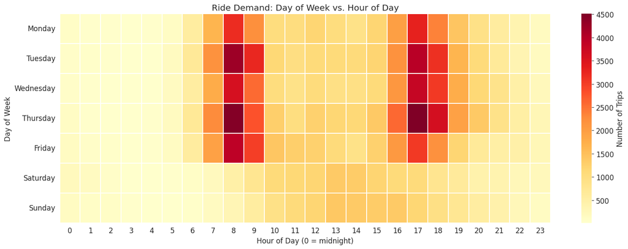

```python
def plot_demand_heatmap(data):
    """
    Heatmap of ride frequency grouped by day of week (rows) and hour of day (columns).
    Reveals commuter vs. leisure usage patterns across the week.

    Parameters
    ----------
    data : pd.DataFrame with 'hour' and 'day_of_week' columns
    """
    pivot = data.groupby(['day_of_week', 'hour']).size().unstack(fill_value=0)

    fig, ax = plt.subplots(figsize=(16, 6))
    sns.heatmap(pivot, cmap='YlOrRd', linewidths=0.3,
                ax=ax, cbar_kws={'label': 'Number of Trips'})

    ax.set_title('Ride Demand: Day of Week vs. Hour of Day')
    ax.set_xlabel('Hour of Day (0 = midnight)')
    ax.set_ylabel('Day of Week')
    plt.tight_layout()
    plt.savefig('plot_07_heatmap_demand.png', dpi=150, bbox_inches='tight')
    plt.show()


plot_demand_heatmap(df)
```

**Observation:** A clear commuter pattern appears on weekdays, with two distinct peaks: 8 AM (morning rush) and 5-6 PM (evening rush). On weekends, demand is spread more evenly across midday hours (10 AM-4 PM), indicating leisure use. Weekday nights and early mornings see very low activity.

### Talk about some of the relationships you observed in this part of the investigation. How did the feature(s) of interest vary with other features in the dataset?

**Gender** shows a smaller but real effect: Female and 'Other' riders take slightly longer trips than Male riders. However, the IQR overlap is substantial, meaning this difference is less practically significant than the user type effect.

**Age** shows essentially no linear relationship with duration (Pearson r close to 0). How old a rider is does not predict how long they ride.

The **demand heatmap** revealed strong temporal structure: weekday demand is commute-driven (two sharp daily peaks), while weekend demand spreads across midday — a classic leisure pattern.

### Did you observe any interesting relationships between the other features (not the main feature(s) of interest)?

Yes — the temporal demand pattern itself is an interesting relationship between `hour`, `day_of_week`, and ride count (not duration). The two weekday rush-hour peaks are sharp and consistent Monday through Friday, then completely disappear on weekends, replaced by a single broad midday curve. This mirrors classic urban commuter behavior and suggests the majority of Subscriber rides are tied to work schedules.

The gender imbalance (Male ~74%) also interacts with user type — it will be worth checking in the multivariate section whether the user type effect on duration holds equally for Male and Female riders.

## Multivariate Exploration

> Create plots of three or more variables to investigate your data even further. Make sure that your investigations are justified, and follow from your work in the previous sections.

### Q8: How do gender and user type together affect trip duration? (Facet Plot)

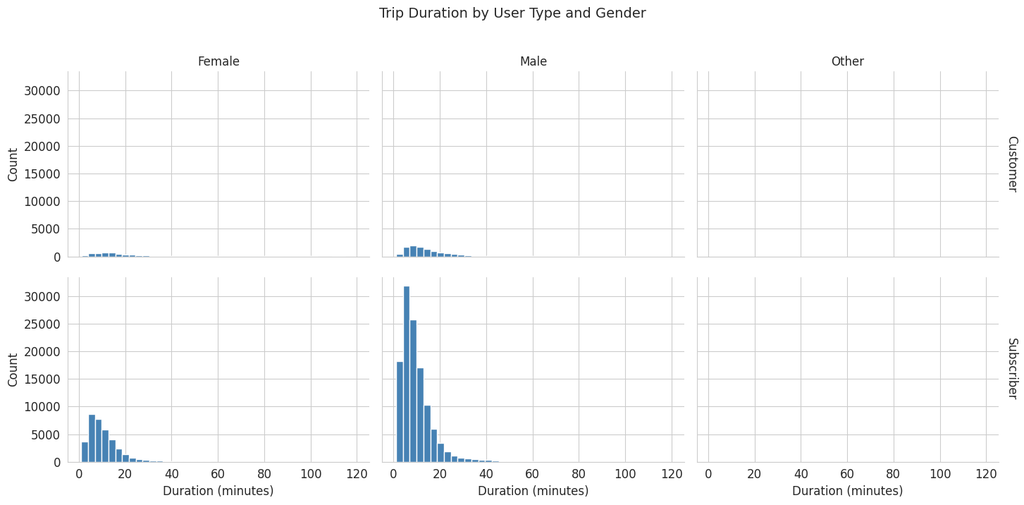

```python
def plot_duration_facet(data):
    """
    FacetGrid of trip duration histograms split by gender (columns) and user_type (rows).
    Allows direct comparison of the user_type effect across genders.

    Parameters
    ----------
    data : pd.DataFrame with 'member_gender', 'user_type', and 'duration_min' columns
    """
    g = sns.FacetGrid(
        data[data['member_gender'].isin(['Male', 'Female'])],
        col='member_gender',
        row='user_type',
        height=3.5,
        aspect=1.4,
        margin_titles=True
    )
    g.map(plt.hist, 'duration_min', bins=40, color='steelblue', edgecolor='white')
    g.set_axis_labels('Duration (minutes)', 'Count')
    g.set_titles(col_template='{col_name}', row_template='{row_name}')
    g.figure.suptitle('Trip Duration by User Type and Gender', y=1.02, fontsize=14)
    plt.tight_layout()
    plt.savefig('plot_08_facet_gender_usertype.png', dpi=150, bbox_inches='tight')
    plt.show()


plot_duration_facet(df)
```

**Observation:** The facet plot confirms that the user type effect holds consistently across both genders. Subscriber distributions (Male and Female) are tightly clustered at short durations, while Customer distributions have heavier right tails in both gender panels. Female Customers show the widest spread, suggesting the most diverse riding behavior in that subgroup.

### Q9: How does age relate to duration across user types? (Scatter Plot with Multiple Encodings)

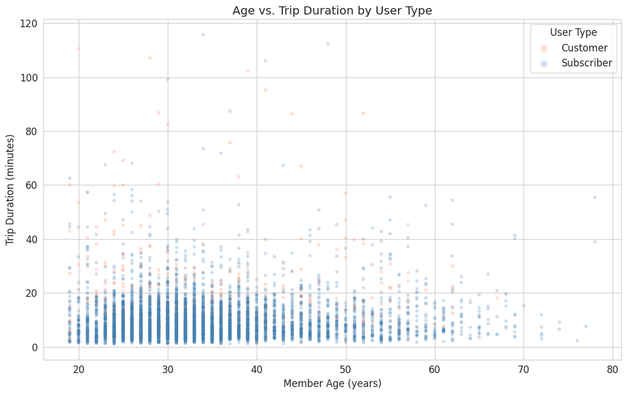

```python
def plot_multivariate_scatter(data, sample_n=6000):
    """
    Scatter plot of member age vs. trip duration with color encoding for user_type.
    Uses transparency and a random sample to manage overplotting on the full dataset.

    Parameters
    ----------
    data     : pd.DataFrame with 'member_age', 'duration_min', and 'user_type' columns
    sample_n : int, number of sample points to plot
    """
    sample = data.sample(n=min(sample_n, len(data)), random_state=42)

    fig, ax = plt.subplots(figsize=(11, 7))
    colors = {'Subscriber': 'steelblue', 'Customer': 'coral'}

    for utype, group in sample.groupby('user_type'):
        ax.scatter(group['member_age'], group['duration_min'],
                   alpha=0.25, s=18, color=colors[utype],
                   label=utype, edgecolors='none')

    ax.set_title('Age vs. Trip Duration by User Type')
    ax.set_xlabel('Member Age (years)')
    ax.set_ylabel('Trip Duration (minutes)')
    ax.legend(title='User Type', markerscale=2)
    plt.tight_layout()
    plt.savefig('plot_09_scatter_multivar.png', dpi=150, bbox_inches='tight')
    plt.show()


plot_multivariate_scatter(df)
```

### Q10: Does the user type duration gap vary by day of week? (Clustered Bar Chart)

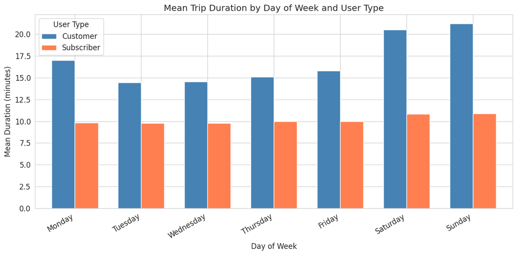

```python
def plot_clustered_bar_day_usertype(data):
    """
    Clustered bar chart of mean trip duration by day of week, grouped by user type.
    Tests whether the Subscriber/Customer duration gap changes across the week.

    Parameters
    ----------
    data : pd.DataFrame with 'day_of_week', 'user_type', and 'duration_min' columns
    """
    pivot = (data.groupby(['day_of_week', 'user_type'])['duration_min']
                 .mean()
                 .unstack())

    fig, ax = plt.subplots(figsize=(12, 6))
    pivot.plot(kind='bar', ax=ax, color=['steelblue', 'coral'],
               edgecolor='white', width=0.7)

    ax.set_title('Mean Trip Duration by Day of Week and User Type')
    ax.set_xlabel('Day of Week')
    ax.set_ylabel('Mean Duration (minutes)')
    ax.set_xticklabels(ax.get_xticklabels(), rotation=30, ha='right')
    ax.legend(title='User Type')
    plt.tight_layout()
    plt.savefig('plot_10_clustered_bar_day.png', dpi=150, bbox_inches='tight')
    plt.show()


plot_clustered_bar_day_usertype(df)
```

**Observation:** The user type gap persists every day, but widens notably on weekends: Customer durations spike on Saturday and Sunday while Subscriber durations remain flat. This reinforces the commuter-vs-leisure story — Subscribers maintain short, routine trips every day, while Customers ride longer when freed from weekday time constraints.

### Q11: Pairwise relationships across duration, age, and hour (Plot Matrix)

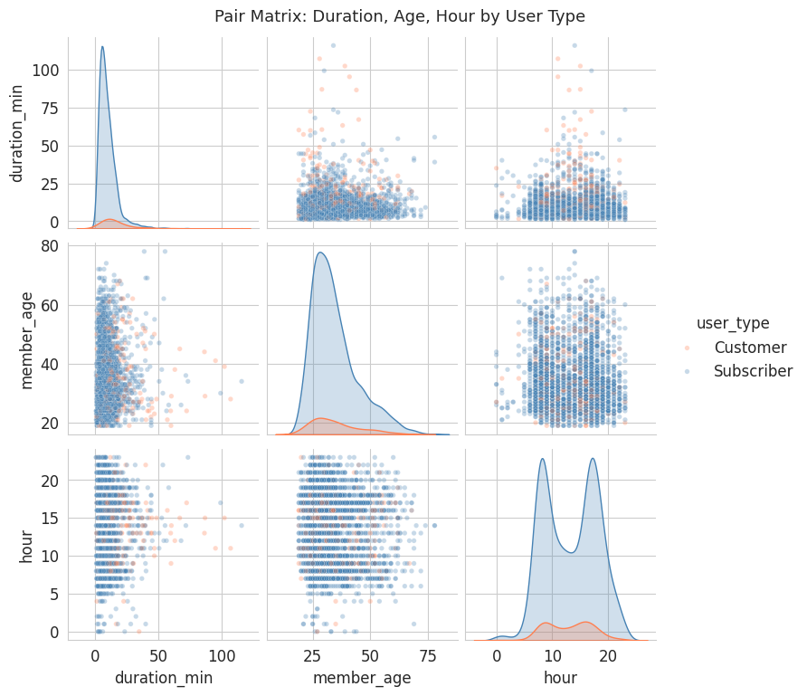

```python
def plot_pair_matrix(data, sample_n=3000):
    """
    Seaborn pairplot matrix showing pairwise scatter plots and KDE diagonals
    for duration_min, member_age, and hour — colored by user_type.

    Parameters
    ----------
    data     : pd.DataFrame
    sample_n : int, sample size for rendering performance
    """
    sample = data.sample(n=min(sample_n, len(data)), random_state=42)
    cols = ['duration_min', 'member_age', 'hour']

    g = sns.pairplot(
        sample[cols + ['user_type']],
        hue='user_type',
        palette={'Subscriber': 'steelblue', 'Customer': 'coral'},
        plot_kws={'alpha': 0.3, 's': 15},
        diag_kind='kde'
    )
    g.figure.suptitle('Pair Matrix: Duration, Age, Hour by User Type', y=1.02, fontsize=13)
    plt.savefig('plot_11_pair_matrix.png', dpi=150, bbox_inches='tight')
    plt.show()


plot_pair_matrix(df)
```

### Talk about some of the relationships you observed in this part of the investigation. Were there features that strengthened each other in terms of looking at your feature(s) of interest?

**User type and day of week** strengthened each other considerably. The user type box plot showed Customers ride longer, and the weekend heatmap showed broader demand. Combined in the clustered bar chart, both effects compound: Customer duration is always longer, and it grows even larger on weekends. This combination tells a cleaner story than either variable alone.

Similarly, **user type and gender** reinforced each other in the facet plot: the user type effect on duration is consistent and roughly equal in magnitude for both Male and Female riders, ruling out the possibility that the user type finding was driven purely by a gender composition difference.

### Were there any interesting or surprising interactions between features?

The most surprising finding was how **completely age failed to predict duration**. Intuitively, one might expect younger or older riders to behave differently — but the scatter plot and pair matrix both show near-zero correlation across all age groups and both user types. User type simply overwhelms any potential age signal.

## Conclusions

### Reflection on the Exploration Process

The exploration followed a natural progression: distributions first, then pairwise relationships, then three-variable interactions. The most important decision was to verify whether the user type effect held after controlling for other variables — the facet plot (gender x user type) and clustered bar chart (day x user type) both confirmed it did, consistently.

The three most impactful visualizations — the **demand heatmap**, the **user type box plot**, and the **weekend clustered bar chart** — together tell a coherent story about two distinct rider populations: daily commuters on subscriptions and casual leisure users. These three will form the core of the Part II explanatory presentation.

```python
!jupyter nbconvert --to html "Part_I_exploration_template.ipynb"
```

```
[NbConvertApp] Converting notebook Part_I_exploration_template.ipynb to html
[NbConvertApp] WARNING | Alternative text is missing on 11 image(s).
[NbConvertApp] Writing 1491551 bytes to Part_I_exploration_template.html
```

```python
!jupyter nbconvert --to notebook --output backup_notebook.ipynb "Part_I_exploration_template.ipynb"
```

```
[NbConvertApp] Converting notebook Part_I_exploration_template.ipynb to notebook
[NbConvertApp] Writing 1149885 bytes to backup_notebook.ipynb
```

```python
import os

os.rename('Part_I_exploration_template.ipynb', 'Part_I_notebook.ipynb')
```

```python
!jupyter nbconvert --to html Part_I_notebook.ipynb
```

```
[NbConvertApp] Converting notebook Part_I_notebook.ipynb to html
[NbConvertApp] WARNING | Alternative text is missing on 11 image(s).
[NbConvertApp] Writing 1484040 bytes to Part_I_notebook.html
```